# Visualisation 1

Гладышев Никита Сергеевич

2024-09-27

## Столбчатые диаграммы

1. Постройте барплот (столбчатую диаграмму), отражающую распределение числа студентов по курсу обучения. Примените любую из встроенных тем ggplot. Раскрасьте столбики любым понравившимся вам цветом (можно использовать как словесные обозначения, так и гекскоды). Добавьте цвет контура столбиков. (1 б).

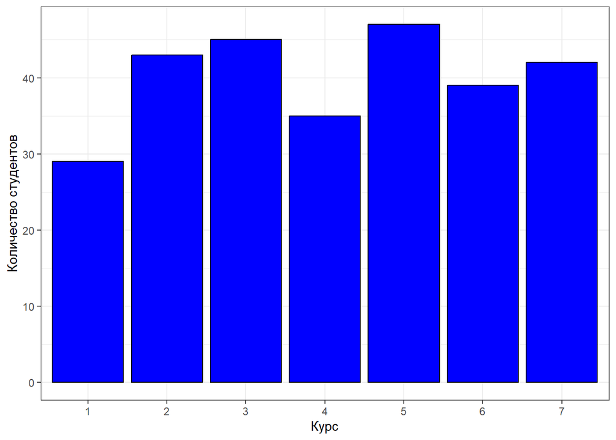

```r
data <- read.csv ("hogwarts.csv")
data <- data %>%
  mutate (across (where (is.character), as.factor), across (2:4, as.factor))


ggplot (data, aes (course)) +
  geom_bar (color = "black", fill = "blue" ) +
  theme_bw () +
  labs (x = "Курс", y = "Количество студентов")
```

2. Создайте новый барплот, отражающий распределение числа студентов по факультету. Добавьте на график вторую факторную переменную – происхождение (bloodStatus). Модифицируйте при помощи аргумента position графика так, чтобы каждый столбец показывал распределение факультета по чистоте крови в долях. Примените произвольную тему. Запишите текстом в rmd-документе, какой вывод можно сделать из графика? (1 б).

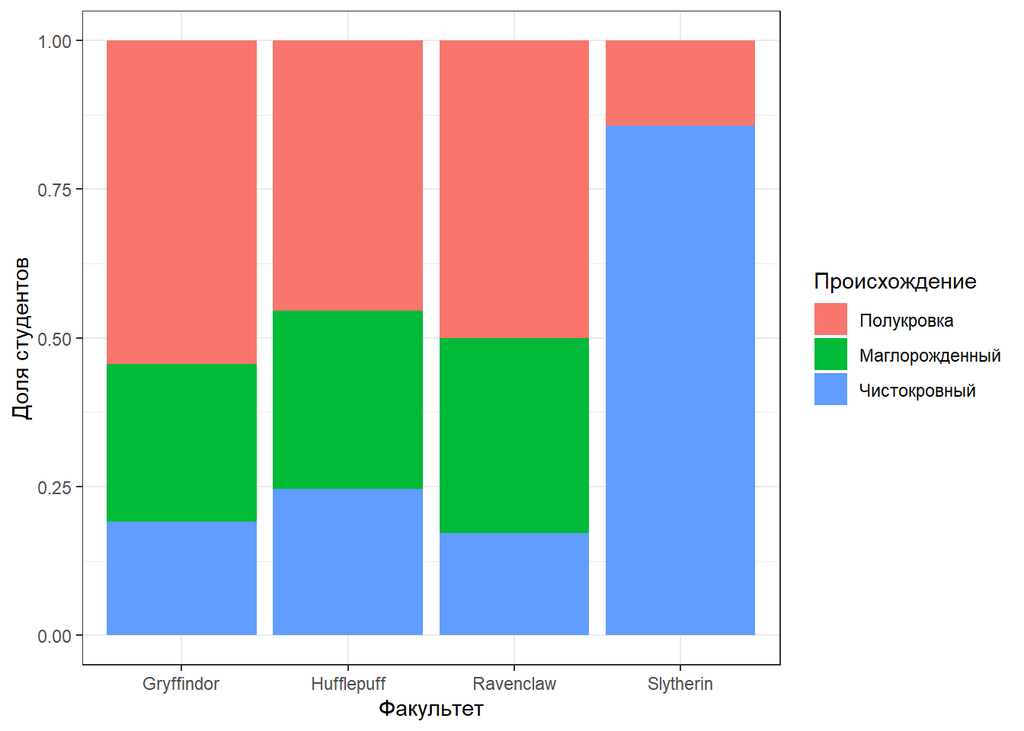

```r
ggplot (data, aes (house, fill = blood_status)) +
  geom_bar (position = "fill") +
  theme_bw () +
  labs (x = "Факультет", y = "Доля студентов", fill = "Происхождение") +
  scale_fill_discrete(labels = c("Half-blood" = "Полукровка",
                                 "Muggle-borned" = "Маглорожденный",
                                 "Pure-blood" = "Чистокровный"))
```

*Ответ*: На факультете Слизерин имеется значительный перевес в доле “чистокровных” волшебников, при полном отстутствии маглорожденных, что может свидетельствовать о дискриминации (не исключено, что со стороны распределяющей шляпы ;))

3. Модифицируйте датасет таким образом, чтобы в нем остались только чистокровные (pure-blood) и маглорожденные студенты (muggle-born). Создайте на основе этих данных график из пункта 2. Добавьте горизонтальную пунктирную линию произвольного цвета на уровне 50%. Дайте осям название на русском языке (1б). Дополнительно: переименуйте на русский язык категории легенды pure-blood и muggle-born (0.5 б).

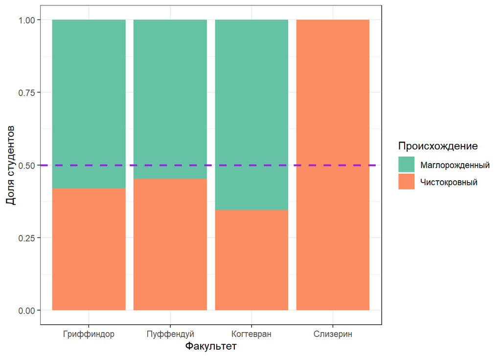

```r
data %>% filter (blood_status %in% c ("Pure-blood", "Muggle-borned")) %>%
  ggplot (aes (house, fill = blood_status)) +
  geom_bar (position = "fill") +
  geom_hline(aes (yintercept = 0.5), linetype = "dashed", color = "purple", size = 1) +
  theme_bw () +
  labs (x = "Факультет", y = "Доля студентов", fill = "Происхождение") +
  scale_fill_brewer(palette = "Set2", labels = c("Pure-blood" = "Чистокровный",
                                                 "Muggle-borned" = "Маглорожденный")) +
  scale_x_discrete(labels = c("Gryffindor" = "Гриффиндор",
                              "Slytherin" = "Слизерин",
                              "Ravenclaw" = "Когтевран",
                              "Hufflepuff" = "Пуффендуй"))
```

## Боксплоты

1. Отобразите распределение баллов, заработанных студентами на 3-й неделе обучения, по факультетам. Отсортируйте факультеты в порядке убывания медианного балла за 3-ю неделю (мы не останавливались на этом в лекции, но упомянутая в ней функция по умолчанию сортирует именно по медиане, так что в этом случае дополнительных аргументов передавать не следует). (1 б.)

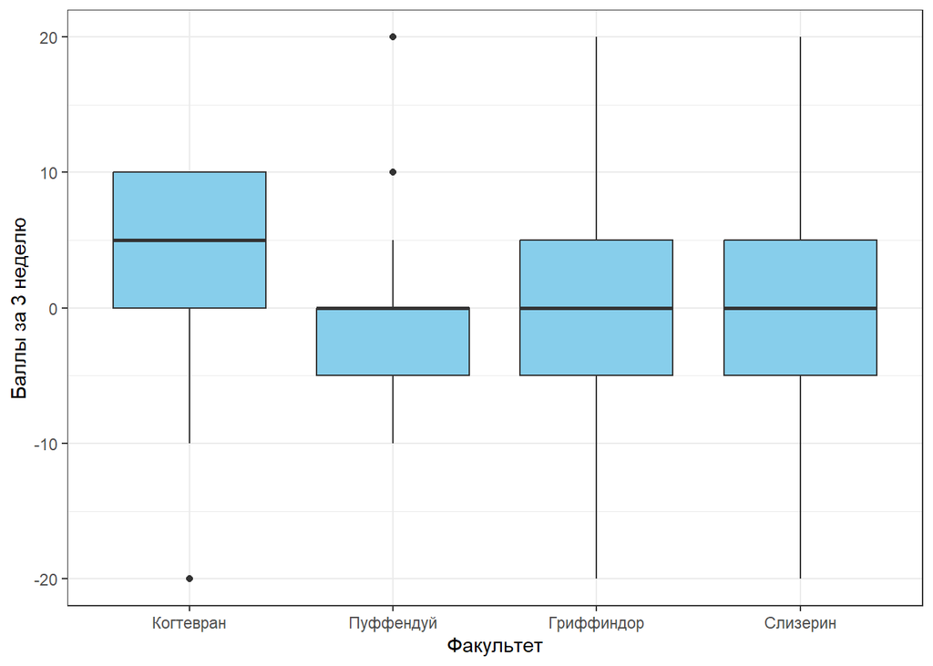

```r
ggplot (data, aes (x = reorder(house, -week.3), y = week.3)) +
  geom_boxplot(fill = "skyblue") +
  theme_bw() +
  labs(x = "Факультет", y = "Баллы за 3 неделю") +
  scale_x_discrete(labels = c("Gryffindor" = "Гриффиндор",
                              "Slytherin" = "Слизерин",
                              "Ravenclaw" = "Когтевран",
                              "Hufflepuff" = "Пуффендуй"))
```

2. Добавьте отображение разными цветами для происхождения студентов (bloodStatus). Добавьте на боксплот вырезку (notch). Настройте для данного чанка размер изображения 14:14 дюймов. Приведите названия осей к корректному виду. (1 б.)

[output not shown]

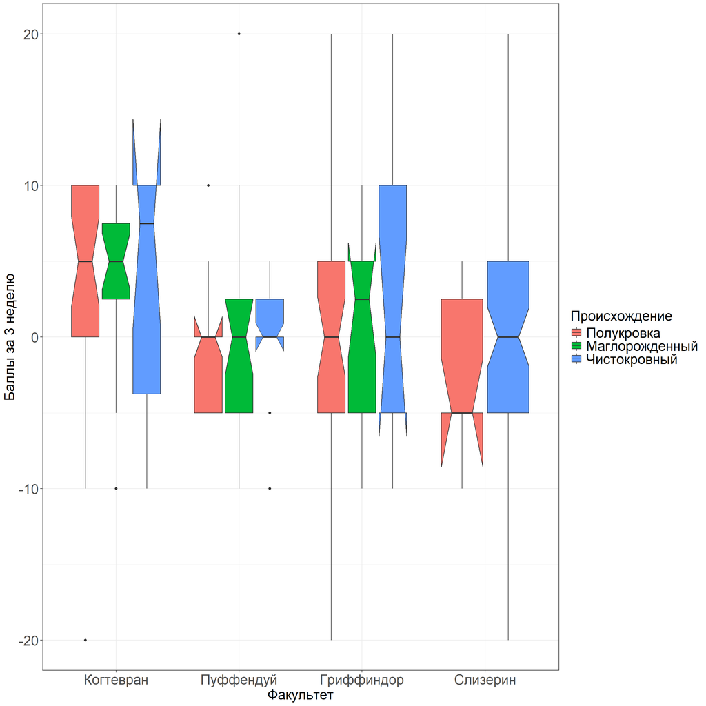

```r
ggplot (data, aes (x = reorder(house, -week.3), y = week.3, fill = blood_status)) +
  geom_boxplot(notch = TRUE) +
  theme_bw() +
  labs(fill = "Происхождение", x = "Факультет", y = "Баллы за 3 неделю") +
  scale_x_discrete(labels = c("Gryffindor" = "Гриффиндор",
                              "Slytherin" = "Слизерин",
                              "Ravenclaw" = "Когтевран",
                              "Hufflepuff" = "Пуффендуй")) +
  scale_fill_discrete(labels = c("Half-blood" = "Полукровка",
                                 "Muggle-borned" = "Маглорожденный",
                                 "Pure-blood" = "Чистокровный")) +
  theme(
    axis.text.x = element_text(size = 20),
    axis.text.y = element_text(size = 20),
    axis.title.x = element_text(size = 20),
    axis.title.y = element_text(size = 20),
    legend.title = element_text(size = 20),
    legend.text = element_text(size = 20))
```

3. Добавьте на график джиттер-плот. Удалите отображение выбросов у боксплота. Видоизмените по своему вкусу толщину линий и ширину боксплота. (1 б.) Дополнительно: Добавьте название графика и подпись (0.5 б.)

[output not shown]

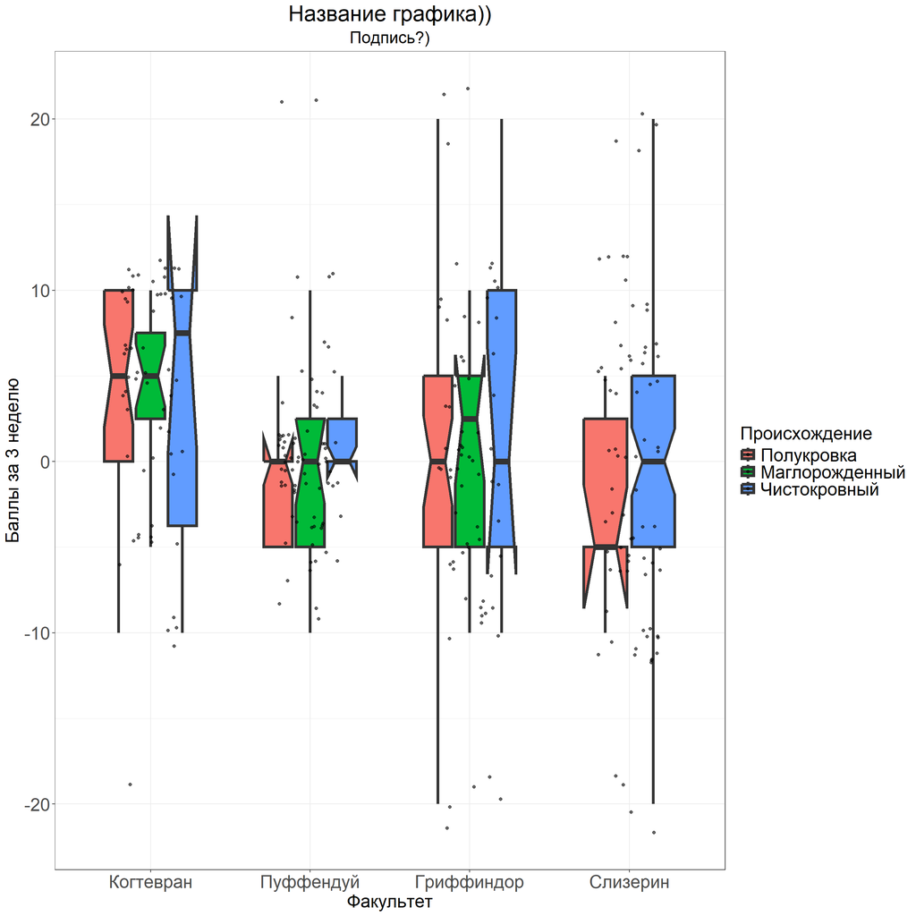

```r
ggplot (data, aes (x = reorder(house, -week.3), y = week.3, fill = blood_status)) +
  geom_boxplot(notch = TRUE, outlier.shape = NA, size = 1.5, width = 0.6) +
  geom_jitter(width = 0.2, alpha = 0.6) +
  theme_bw() +
  labs(title = "Название графика))", subtitle = "Подпись?)", fill = "Происхождение", x = "Факультет", y = "Баллы за 3 неделю") +
  scale_x_discrete(labels = c("Gryffindor" = "Гриффиндор",
                              "Slytherin" = "Слизерин",
                              "Ravenclaw" = "Когтевран",
                              "Hufflepuff" = "Пуффендуй")) +
  scale_fill_discrete(labels = c("Half-blood" = "Полукровка",
                                 "Muggle-borned" = "Маглорожденный",
                                 "Pure-blood" = "Чистокровный")) +
  theme(
    axis.text.x = element_text(size = 20),
    axis.text.y = element_text(size = 20),
    axis.title.x = element_text(size = 20),
    axis.title.y = element_text(size = 20),
    legend.title = element_text(size = 20),
    legend.text = element_text(size = 20),
    plot.title = element_text(size = 24, hjust = 0.5),
     plot.subtitle = element_text(size = 18, hjust = 0.5))
```

## Разное

1. Постройте “леденцовый график” (lollipop-plot) для количества набранных студентами 5-го курса баллов за весь учебный год (по оси ординат – id студента, по оси абсцисс – итоговый балл). Отсортируйте студентов в порядке убывания итогового балла. Раскрасьте точки на “леденцах” в зависимости от сердцевины волшебной палочки. Палочки с сердечной жилой дракона должны быть красного цвета, с пером феникса – желтого, с волосом единорога – серого. (1 б.)

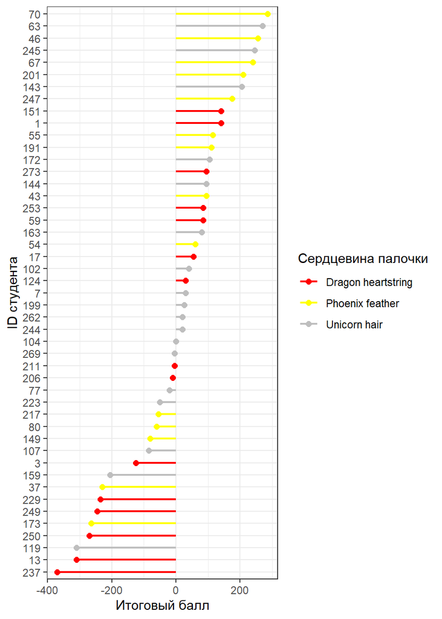

```r
data %>%
  filter(course == 5) %>%
  arrange(desc(result)) %>%
  ggplot(aes(x = result, y = reorder(id, result), color = wand)) +
  geom_segment(aes(x = 0, xend = result, y = reorder(id, result), yend = reorder(id, result)), size = 0.8) +
  geom_point(size = 2) +
  scale_color_manual(values = c("Dragon heartstring" = "red",
                                "Phoenix feather" = "yellow",
                                "Unicorn hair" = "gray")) +
  theme_bw() +
  labs(x = "Итоговый балл",
       y = "ID студента",
       color = "Сердцевина палочки")
```

2. Постройте гистограмму распредления баллов за экзамен по астрономии. Выделите цветом факультет Слизерин. Примените 18-й кегль к тексту на осях x, y и легенды. Название оси y и легенды запишите 20-м кеглем, оси x – 22-м. Измените название оси y на “Number of students”. (1 б.)

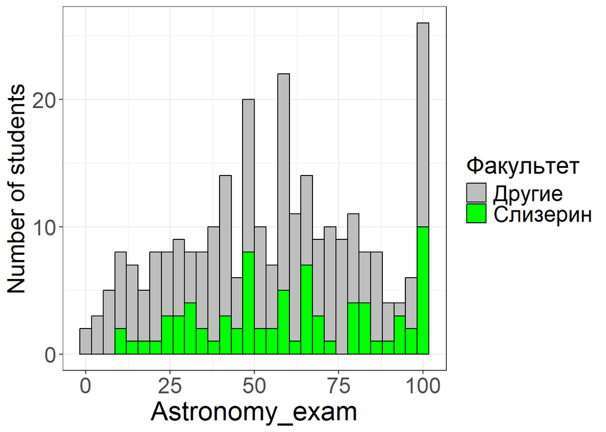

```r
ggplot (data, aes (Astronomy_exam, fill = (house == "Slytherin"))) +
  geom_histogram(color = "black") +
  scale_fill_manual(values = c("TRUE" = "green", "FALSE" = "gray"), labels = c("FALSE" = "Другие", "TRUE" = "Слизерин")) +
  theme_bw() +
  labs(y = "Number of students", fill = "Факультет") +
  theme(
    axis.text.x = element_text(size = 18),
    axis.text.y = element_text(size = 18),
    axis.title.x = element_text(size = 22),
    axis.title.y = element_text(size = 20),
    legend.title = element_text(size = 20),
    legend.text = element_text(size = 18)
  )
```

3. На лекции мы использовали комбинацию theme_bw(), и созданной нами theme_custom, чтобы одновременно сделать фон белым и увеличить шрифт. Модифицируйте theme_custom таким образом, чтобы она и выполняла свои прежние функции, и делала фон белым без помощи theme_bw(). Примените новую кастомную тему к графику, полученному в последнем пункте блока по боксплотам (1.5 б).

[output not shown]

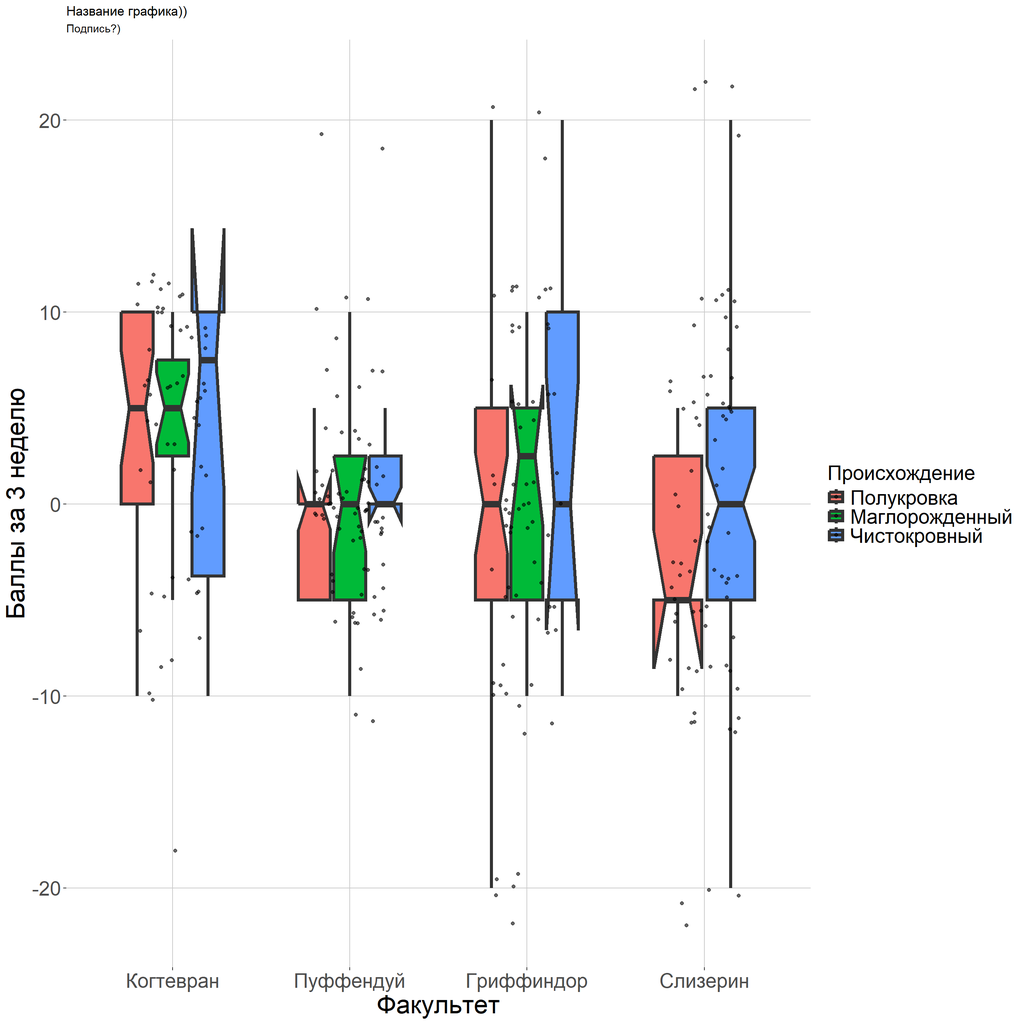

```r
# Задаем тему custom
theme_custom <- theme(
    axis.text = element_text(size = 20),
    axis.title = element_text(size = 25),
    # axis.text.x = element_text(angle = 15),
    legend.title = element_text(size = 20),
    legend.text = element_text(size = 20)
  )

# Перезадаем тему custom

theme_custom <- theme(
    axis.text = element_text(size = 20),
    axis.title = element_text(size = 25),
    # axis.text.x = element_text(angle = 15),
    legend.title = element_text(size = 20),
    legend.text = element_text(size = 20),
    panel.background = element_rect(fill = "white", color = NA),
    plot.background = element_rect(fill = "white", color = NA),
    panel.grid.major = element_line(color = "grey80"),
    panel.grid.minor = element_blank()
)

ggplot (data, aes (x = reorder(house, -week.3), y = week.3, fill = blood_status)) +
  geom_boxplot(notch = TRUE, outlier.shape = NA, size = 1.5, width = 0.6) +
  geom_jitter(width = 0.2, alpha = 0.6) +
  labs(title = "Название графика))", subtitle = "Подпись?)", fill = "Происхождение", x = "Факультет", y = "Баллы за 3 неделю") +
  scale_x_discrete(labels = c("Gryffindor" = "Гриффиндор",
                              "Slytherin" = "Слизерин",
                              "Ravenclaw" = "Когтевран",
                              "Hufflepuff" = "Пуффендуй")) +
  scale_fill_discrete(labels = c("Half-blood" = "Полукровка",
                                 "Muggle-borned" = "Маглорожденный",
                                 "Pure-blood" = "Чистокровный")) +
  theme_custom
```

```r
#  theme(
#    axis.text.x = element_text(size = 20),
#    axis.text.y = element_text(size = 20),
#    axis.title.x = element_text(size = 20),
#    axis.title.y = element_text(size = 20),
#   legend.title = element_text(size = 20),
#    legend.text = element_text(size = 20),
#    plot.title = element_text(size = 24, hjust = 0.5),
#     plot.subtitle = element_text(size = 18, hjust = 0.5))
```

## Фасетирование

1. Напишите, какой, по вашему мнению, способ фасетирования (по строкам или по столбцам) лучше использовать для визуализации гистограммы. Почему? А какой для визуализации violin-plot? Почему? Можно ли вывести общее правило? (1.5 б)

*Ответ*: Для гистограммы лучше использовать фасетирование по строкам, так как это облегчает сравнение высоты столбиков и выравнивает оси X, что делает распределение более читабельным и позволяет сравнить меры вариатифвности и меры центральной тенденции (приблизительно). Для violin-plot предпочтительнее фасетирование по столбцам, так как это позволяет выровнять оси Y и облегчает сравнение распределений (тех же характеристик). Общее правило: фасетирование по строкам подходит для сравнения высоты элементов, а фасетирование по столбцам — для сравнения формы и вертикальных характеристик.

2. Постройте гистограмму для результата любого выбранного вами экзамена, кроме зельеварения. Настройте оптимальное на ваш взгляд число столбцов гистограммы. Выполните фасетирование по курсу. Постарайтесь, чтобы график был по возможности компактным. (1 б.).

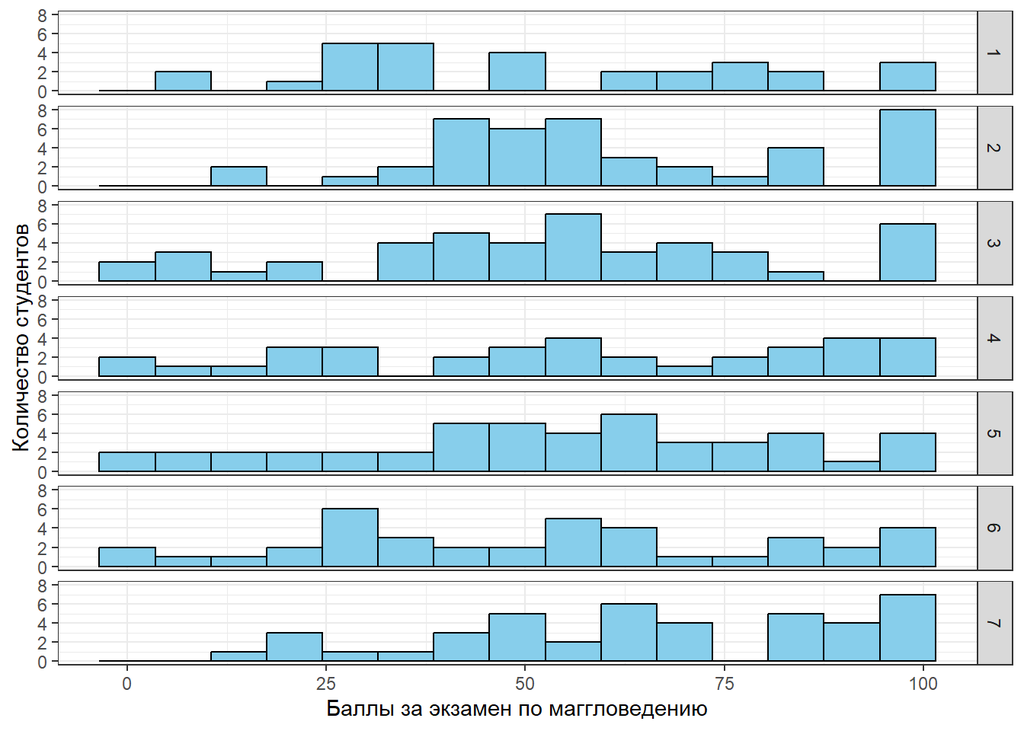

```r
ggplot (data, aes (x = Muggle.studies_exam)) +
  geom_histogram(binwidth = 7, color = "black", fill = "skyblue") +
  facet_grid(course~.) +
  theme_bw()+
  labs(x = "Баллы за экзамен по маггловедению",
       y = "Количество студентов")
```

3. Отобразите на одном графике распределение плотности вероятности для оценки студентов на экзамене по защите от темных искусств и на экзамене по травологии. Раскрасьте их в любые выбранные вами цвета, постарайтесь, чтобы оба распределения отображались целиком. Примените тему из 3-го пункта блока “Разное”. Сделайте фасетирование по полу (1 б.).

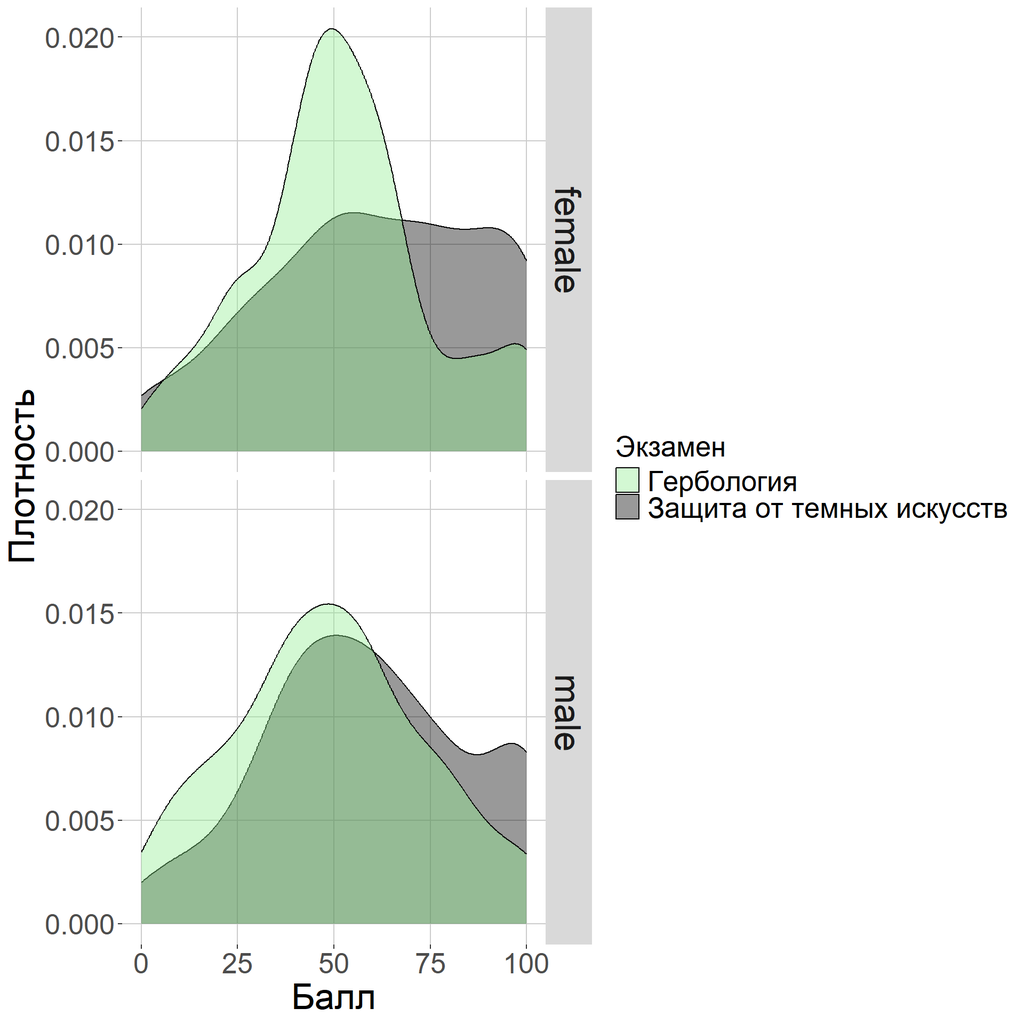

```r
ggplot(data) +
  geom_density(aes(x = Defence.against.the.dark.arts_exam, fill = "Защита от темных искусств"), alpha = 0.4) +
  geom_density(aes(x = Herbology_exam, fill = "Гербология"), alpha = 0.4) +
  theme_custom +
  facet_grid(sex ~ .) +
  scale_fill_manual(values = c("Защита от темных искусств" = "black", "Гербология" = "lightgreen")) +
  labs(x = "Балл", y = "Плотность", fill = "Экзамен") +
  theme(strip.text = element_text(size = 25))
```